# Interactive effects of task repetition, task motivation and task engagement on CAL in L2 writing

Webpage created and maintained by Reza Norouzian* © 2022-present

Reza Norouzian

1/26/2023

# 1 Study Design

We adopted a *Latin Square* design for our study. Following this design, we randomly assigned our participants to either receiving the tasks in a *“simple-to-complex”* (`s2c`) or *“complex-to-simple”* (`c2s`) order. As a result, participants in the `s2c` group completed our simple task at odd time points ($1$ and $3$) and complex task at even time points ($2$ and $4$). Conversely, participants in the `c2s` group completed our complex task at odd time points ($1$ and $3$) and simple task at even time points ($2$ and $4$). Figure 1 visually depicts our full design for two participants (#1 and #51) in these two groups.

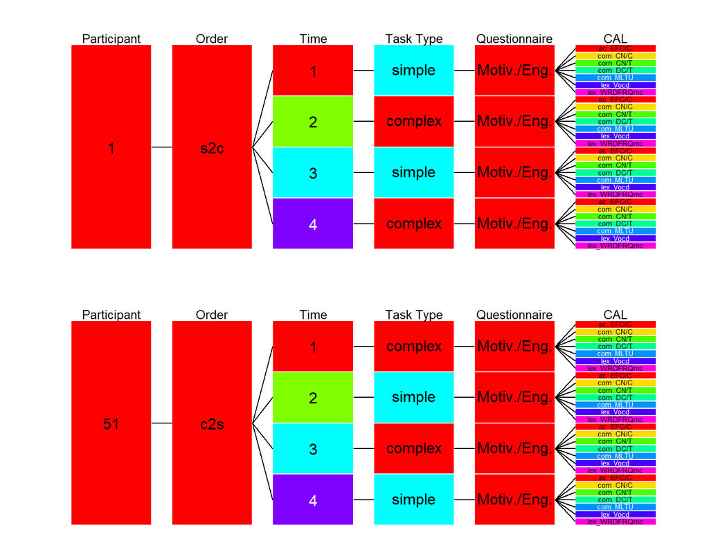

Fig. 1. Design of the study

In addition, the following table shows the distribution of the measurements on the CAL measures (dependent variables) we collected from our participants ($N =100$) across our time points given the order to which they were each assigned:

Distribution of CAL measurements

| n (group) | Order | n (CAL Measures) | Time | Measurements |
| --- | --- | --- | --- | --- |
| 50 | c2s | 7 | 1 | 350 |
| 50 | s2c | 7 | 1 | 350 |
| 50 | c2s | 7 | 2 | 350 |
| 50 | s2c | 7 | 2 | 350 |
| 50 | c2s | 7 | 3 | 350 |
| 50 | s2c | 7 | 3 | 350 |
| 50 | c2s | 7 | 4 | 350 |
| 50 | s2c | 7 | 4 | 350 |
| Overall | Overall | Overall | Overall | 2800 |

As shown in the Table above, our design with respect to time and order of the writing task was balanced with no attrition or loss of data due to students’ dropping out or delivering incomprehensible writing tasks.

# 2 Statistical modeling

In addition, these CAL measures were on various scales of measurements. For instance, our measure of accuracy (`EFC/C`) was on a proportion-type scale (ranging from $0$ to $1$). On the other hand, other measures of lexical complexity (e.g., `Vocd`) were on unbounded numerical scales.

As a result, we allowed each CAL measure to be separately modeled based on its unique characteristics for the participants.

In modeling the impact of our independent variables (e.g., task repetition) on the CAL measures, it seemed logical to empirically verify a few purely theoretical assumptions:

1. Our model-predicted CAL scores are likely more similar for each participant than those for other participants (participants have a clustering effect on our inferential conclusions, which if ignored, makes them prone to being Type I errors).
2. The impact of task repetition on CAL scores may vary across participants (there is (co-)variation in task repetition’s impact among participants).
3. The moderating impact of our moderators (*task difficulty, task motivation, engagement variables*) on task repetition may vary across participants (there is (co-)variation in our moderators impact among participants).
4. The moderating impact of our moderators (*task difficulty, task motivation, engagement variables*) at each time of measurement (times 1, 2, 3, and 4) on task repetition may vary across participants (there is (co-)variation in our moderators impact across times of measurement among participants).

We, then, proceeded to empirically verify if these theoretical assumptions apply to our study. While assumption 1 was empirically verified, assumptions 2, 3 and 4 did not apply to our study. An implication of assumption #1 was that our participants were treated as a sample of a wider population L2 learners perhaps with the same range of differences in characteristics as those present in our participants.

The above assumptions aimed to capture the heterogeneity and dependence arising in predictions of our statistical models (*hierarchical assumptions*). Another form of heterogeneity and dependence may arise in what is NOT predicted (i.e., residuals) by our statistical models (*residual assumptions*).

In short, our initial statistical models assumed that their residuals are *independent and similarly spread* across the model-predicted scores (i.e., residual vs. fitted scores) but also across all other predictors of CAL measures used in the model. This assumption is typically violated when: (A) scores on the dependent variable are on a measurement scale that doesn’t directly map onto the distribution the statistical model uses for modeling (e.g., mapping a proportion-type dependent variable onto a normal distribution used in a linear model), and (B) the distribution for dependent variable scores could map onto the distribution the statistical model uses for modeling only conditional on variables other than the dependent variable itself (e.g., predictors, control variables like individual differences etc.). In our case, the *residual assumption* was violated for multiple CAL measures mainly due to the second reason.

Specifically, upon examining these violations, we realized that *task repetition, time on task, and task motivation* were the main variables in our study responsible for these violations. For instance, we realized that higher levels of task motivation were associated with smaller residual spread for the `DC/T` measure of syntactic complexity.

As another example, in addition to a positive non-linear association between the amount of time spent on a writing task and the spread of the residuals, the residuals across different times of CAL measurement were both freely correlated and unevenly spread for the `CN/T` measure of syntactic complexity.

Once the sources of violations were identified, we then directed the statistical model to adapt its default assumptions to the reality of the data connecting the violations of residual assumptions to their underlying reasons. In a way, this process re-calibrated the statistical model to make more realistic predictions and not necessarily consider all initially bad-fitting participants as outliers.

As a graphical validation of our residual modeling process, here is the pattern of residuals on the `CN/T` measure *before* residual modeling:

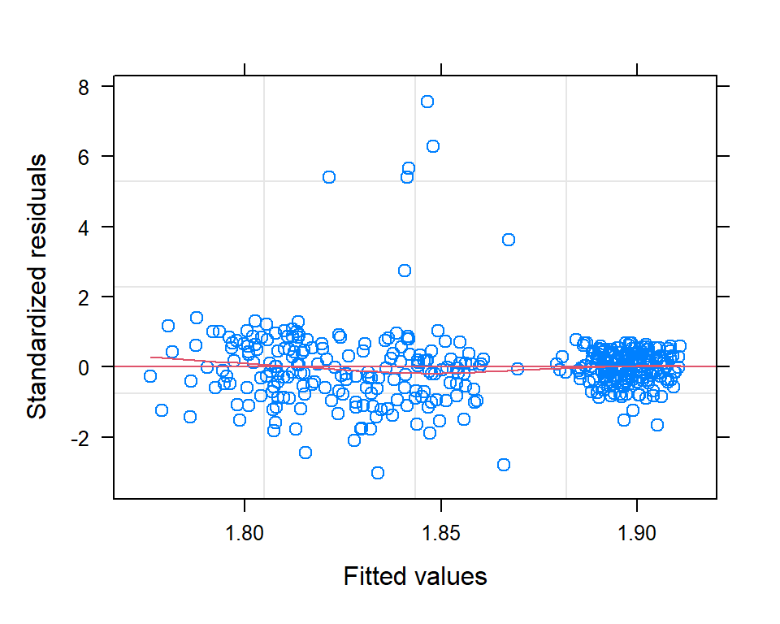

And *after* residual modeling:

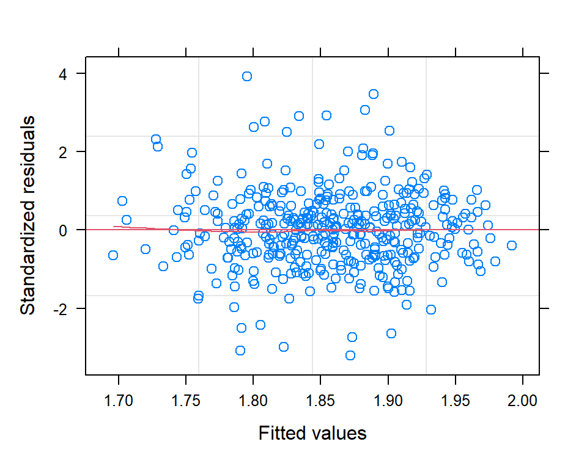

The **after** pattern indicates that now residuals’ have nearly zero association (linear and non-linear) to the model-predicated data (i.e., they are independent), and they are spread more evenly across the model-predicated data.

# 3 RQ1: To what extent can task repetition impact measures of L2 writing syntactic complexity, accuracy, and lexical complexity?

The impact of task repetition on CAL measures

| row no. | CAL Measure | time | Mean | SE | Lower | Upper | t | p-value | Sig. |
| --- | --- | --- | --- | --- | --- | --- | --- | --- | --- |
| 1 | ac_EFC/C | 1 | 0.584 | 0.012 | 0.561 | 0.608 | 6.914 | 0.000 | *** |
| 2 | ac_EFC/C | 2 | 0.560 | 0.014 | 0.533 | 0.587 | 4.332 | 0.000 | *** |
| 3 | ac_EFC/C | 3 | 0.687 | 0.012 | 0.663 | 0.710 | 14.240 | 0.000 | *** |
| 4 | ac_EFC/C | 4 | 0.643 | 0.012 | 0.620 | 0.666 | 11.503 | 0.000 | *** |
| 5 | com_DC/T | 1 | 0.688 | 0.013 | 0.662 | 0.713 | 12.899 | 0.000 | *** |
| 6 | com_DC/T | 2 | 0.661 | 0.015 | 0.630 | 0.690 | 9.651 | 0.000 | *** |
| 7 | com_DC/T | 3 | 0.720 | 0.014 | 0.692 | 0.746 | 13.874 | 0.000 | *** |
| 8 | com_DC/T | 4 | 0.705 | 0.013 | 0.678 | 0.731 | 13.521 | 0.000 | *** |
| 9 | com_CN/C | 1 | 1.103 | 0.025 | 1.054 | 1.152 | 44.961 | 0.000 | *** |
| 10 | com_CN/C | 2 | 1.088 | 0.028 | 1.033 | 1.143 | 39.400 | 0.000 | *** |
| 11 | com_CN/C | 3 | 1.104 | 0.027 | 1.051 | 1.157 | 41.193 | 0.000 | *** |
| 12 | com_CN/C | 4 | 1.052 | 0.025 | 1.002 | 1.102 | 41.649 | 0.000 | *** |
| 13 | com_CN/T | 1 | 1.828 | 0.021 | 1.786 | 1.870 | 87.100 | 0.000 | *** |
| 14 | com_CN/T | 2 | 1.809 | 0.012 | 1.785 | 1.833 | 149.936 | 0.000 | *** |
| 15 | com_CN/T | 3 | 1.898 | 0.007 | 1.884 | 1.913 | 258.450 | 0.000 | *** |
| 16 | com_CN/T | 4 | 1.894 | 0.008 | 1.879 | 1.909 | 248.578 | 0.000 | *** |
| 17 | com_MLTU | 1 | 16.157 | 0.157 | 15.845 | 16.469 | 102.746 | 0.000 | *** |
| 18 | com_MLTU | 2 | 15.311 | 0.168 | 14.978 | 15.644 | 91.269 | 0.000 | *** |
| 19 | com_MLTU | 3 | 16.868 | 0.136 | 16.599 | 17.137 | 124.382 | 0.000 | *** |
| 20 | com_MLTU | 4 | 16.872 | 0.138 | 16.599 | 17.145 | 122.499 | 0.000 | *** |
| 21 | lex_Vocd | 1 | 68.086 | 0.795 | 66.509 | 69.663 | 85.645 | 0.000 | *** |
| 22 | lex_Vocd | 2 | 69.058 | 0.895 | 67.283 | 70.834 | 77.177 | 0.000 | *** |
| 23 | lex_Vocd | 3 | 72.036 | 0.868 | 70.313 | 73.759 | 82.958 | 0.000 | *** |
| 24 | lex_Vocd | 4 | 72.140 | 0.819 | 70.516 | 73.765 | 88.106 | 0.000 | *** |
| 25 | lex_WRDFRQmc | 1 | 1.732 | 0.011 | 1.710 | 1.755 | 151.294 | 0.000 | *** |
| 26 | lex_WRDFRQmc | 2 | 1.706 | 0.013 | 1.681 | 1.732 | 132.381 | 0.000 | *** |
| 27 | lex_WRDFRQmc | 3 | 1.750 | 0.013 | 1.725 | 1.775 | 139.900 | 0.000 | *** |
| 28 | lex_WRDFRQmc | 4 | 1.769 | 0.012 | 1.746 | 1.792 | 149.989 | 0.000 | *** |

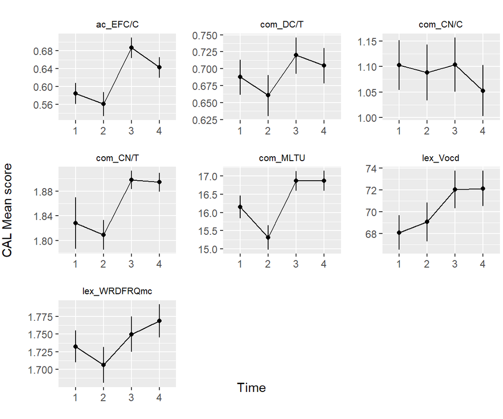

# 4 RQ2: To what extent is that impact moderated by the level of task difficulty?

The impact of task repetition on CAL measures moderated by task difficulty

| row no. | CAL Measure | order | task_dif | time | Mean | SE | Lower | Upper | t | p-value | Sig. |
| --- | --- | --- | --- | --- | --- | --- | --- | --- | --- | --- | --- |
| 1 | ac_EFC/C | c2s | complex | 1 | 0.591 | 0.024 | 0.544 | 0.637 | 3.788 | 0.000 | *** |
| 2 | ac_EFC/C | s2c | simple | 1 | 0.585 | 0.018 | 0.549 | 0.621 | 4.621 | 0.000 | *** |
| 3 | ac_EFC/C | s2c | complex | 2 | 0.542 | 0.026 | 0.491 | 0.593 | 1.625 | 0.105 |  |
| 4 | ac_EFC/C | c2s | simple | 2 | 0.594 | 0.017 | 0.561 | 0.626 | 5.501 | 0.000 | *** |
| 5 | ac_EFC/C | c2s | complex | 3 | 0.739 | 0.016 | 0.706 | 0.769 | 12.623 | 0.000 | *** |
| 6 | ac_EFC/C | s2c | simple | 3 | 0.623 | 0.026 | 0.570 | 0.673 | 4.490 | 0.000 | *** |
| 7 | ac_EFC/C | s2c | complex | 4 | 0.634 | 0.018 | 0.598 | 0.668 | 7.075 | 0.000 | *** |
| 8 | ac_EFC/C | c2s | simple | 4 | 0.644 | 0.024 | 0.596 | 0.689 | 5.710 | 0.000 | *** |
| 9 | com_DC/T | c2s | complex | 1 | 0.687 | 0.027 | 0.632 | 0.737 | 6.365 | 0.000 | *** |
| 10 | com_DC/T | s2c | simple | 1 | 0.687 | 0.022 | 0.642 | 0.728 | 7.741 | 0.000 | *** |
| 11 | com_DC/T | s2c | complex | 2 | 0.657 | 0.030 | 0.597 | 0.714 | 4.921 | 0.000 | *** |
| 12 | com_DC/T | c2s | simple | 2 | 0.661 | 0.020 | 0.621 | 0.699 | 7.547 | 0.000 | *** |
| 13 | com_DC/T | c2s | complex | 3 | 0.715 | 0.020 | 0.675 | 0.753 | 9.404 | 0.000 | *** |
| 14 | com_DC/T | s2c | simple | 3 | 0.725 | 0.030 | 0.663 | 0.779 | 6.534 | 0.000 | *** |
| 15 | com_DC/T | s2c | complex | 4 | 0.686 | 0.021 | 0.644 | 0.725 | 8.064 | 0.000 | *** |
| 16 | com_DC/T | c2s | simple | 4 | 0.728 | 0.028 | 0.670 | 0.779 | 7.039 | 0.000 | *** |
| 17 | com_CN/C | c2s | complex | 1 | 1.132 | 0.050 | 1.034 | 1.230 | 22.840 | 0.000 | *** |
| 18 | com_CN/C | s2c | simple | 1 | 1.072 | 0.039 | 0.994 | 1.149 | 27.308 | 0.000 | *** |
| 19 | com_CN/C | s2c | complex | 2 | 1.156 | 0.054 | 1.050 | 1.263 | 21.595 | 0.000 | *** |
| 20 | com_CN/C | c2s | simple | 2 | 1.014 | 0.036 | 0.943 | 1.085 | 28.320 | 0.000 | *** |
| 21 | com_CN/C | c2s | complex | 3 | 1.134 | 0.040 | 1.055 | 1.213 | 28.429 | 0.000 | *** |
| 22 | com_CN/C | s2c | simple | 3 | 1.079 | 0.057 | 0.965 | 1.193 | 18.802 | 0.000 | *** |
| 23 | com_CN/C | s2c | complex | 4 | 1.134 | 0.040 | 1.055 | 1.213 | 28.416 | 0.000 | *** |
| 24 | com_CN/C | c2s | simple | 4 | 0.972 | 0.054 | 0.865 | 1.079 | 18.034 | 0.000 | *** |
| 25 | com_CN/T | c2s | complex | 1 | 1.811 | 0.030 | 1.751 | 1.871 | 59.829 | 0.000 | *** |
| 26 | com_CN/T | s2c | simple | 1 | 1.860 | 0.034 | 1.793 | 1.927 | 55.159 | 0.000 | *** |
| 27 | com_CN/T | s2c | complex | 2 | 1.828 | 0.022 | 1.785 | 1.871 | 84.185 | 0.000 | *** |
| 28 | com_CN/T | c2s | simple | 2 | 1.785 | 0.017 | 1.751 | 1.819 | 104.510 | 0.000 | *** |
| 29 | com_CN/T | c2s | complex | 3 | 1.913 | 0.011 | 1.891 | 1.936 | 170.822 | 0.000 | *** |
| 30 | com_CN/T | s2c | simple | 3 | 1.881 | 0.020 | 1.841 | 1.920 | 94.319 | 0.000 | *** |
| 31 | com_CN/T | s2c | complex | 4 | 1.892 | 0.012 | 1.868 | 1.917 | 152.608 | 0.000 | *** |
| 32 | com_CN/T | c2s | simple | 4 | 1.902 | 0.020 | 1.863 | 1.940 | 96.899 | 0.000 | *** |
| 33 | com_MLTU | c2s | complex | 1 | 16.083 | 0.301 | 15.485 | 16.681 | 53.399 | 0.000 | *** |
| 34 | com_MLTU | s2c | simple | 1 | 16.281 | 0.253 | 15.779 | 16.782 | 64.373 | 0.000 | *** |
| 35 | com_MLTU | s2c | complex | 2 | 15.439 | 0.320 | 14.804 | 16.074 | 48.258 | 0.000 | *** |
| 36 | com_MLTU | c2s | simple | 2 | 15.220 | 0.226 | 14.772 | 15.667 | 67.487 | 0.000 | *** |
| 37 | com_MLTU | c2s | complex | 3 | 17.050 | 0.203 | 16.647 | 17.453 | 83.899 | 0.000 | *** |
| 38 | com_MLTU | s2c | simple | 3 | 16.636 | 0.322 | 15.997 | 17.274 | 51.709 | 0.000 | *** |
| 39 | com_MLTU | s2c | complex | 4 | 16.976 | 0.219 | 16.541 | 17.411 | 77.367 | 0.000 | *** |
| 40 | com_MLTU | c2s | simple | 4 | 16.741 | 0.313 | 16.121 | 17.362 | 53.518 | 0.000 | *** |
| 41 | lex_Vocd | c2s | complex | 1 | 67.497 | 1.602 | 64.318 | 70.675 | 42.138 | 0.000 | *** |
| 42 | lex_Vocd | s2c | simple | 1 | 68.839 | 1.268 | 66.323 | 71.356 | 54.280 | 0.000 | *** |
| 43 | lex_Vocd | s2c | complex | 2 | 67.782 | 1.731 | 64.348 | 71.216 | 39.167 | 0.000 | *** |
| 44 | lex_Vocd | c2s | simple | 2 | 70.683 | 1.157 | 68.387 | 72.980 | 61.067 | 0.000 | *** |
| 45 | lex_Vocd | c2s | complex | 3 | 72.629 | 1.289 | 70.071 | 75.187 | 56.337 | 0.000 | *** |
| 46 | lex_Vocd | s2c | simple | 3 | 71.098 | 1.855 | 67.417 | 74.779 | 38.325 | 0.000 | *** |
| 47 | lex_Vocd | s2c | complex | 4 | 70.351 | 1.290 | 67.792 | 72.910 | 54.545 | 0.000 | *** |
| 48 | lex_Vocd | c2s | simple | 4 | 73.762 | 1.742 | 70.305 | 77.219 | 42.339 | 0.000 | *** |
| 49 | lex_WRDFRQmc | c2s | complex | 1 | 1.733 | 0.023 | 1.686 | 1.779 | 74.582 | 0.000 | *** |
| 50 | lex_WRDFRQmc | s2c | simple | 1 | 1.734 | 0.018 | 1.697 | 1.770 | 94.271 | 0.000 | *** |
| 51 | lex_WRDFRQmc | s2c | complex | 2 | 1.702 | 0.025 | 1.652 | 1.751 | 67.801 | 0.000 | *** |
| 52 | lex_WRDFRQmc | c2s | simple | 2 | 1.714 | 0.017 | 1.680 | 1.747 | 102.093 | 0.000 | *** |
| 53 | lex_WRDFRQmc | c2s | complex | 3 | 1.757 | 0.019 | 1.720 | 1.794 | 93.961 | 0.000 | *** |
| 54 | lex_WRDFRQmc | s2c | simple | 3 | 1.740 | 0.027 | 1.687 | 1.794 | 64.691 | 0.000 | *** |
| 55 | lex_WRDFRQmc | s2c | complex | 4 | 1.773 | 0.019 | 1.735 | 1.810 | 94.765 | 0.000 | *** |
| 56 | lex_WRDFRQmc | c2s | simple | 4 | 1.764 | 0.025 | 1.713 | 1.814 | 69.798 | 0.000 | *** |

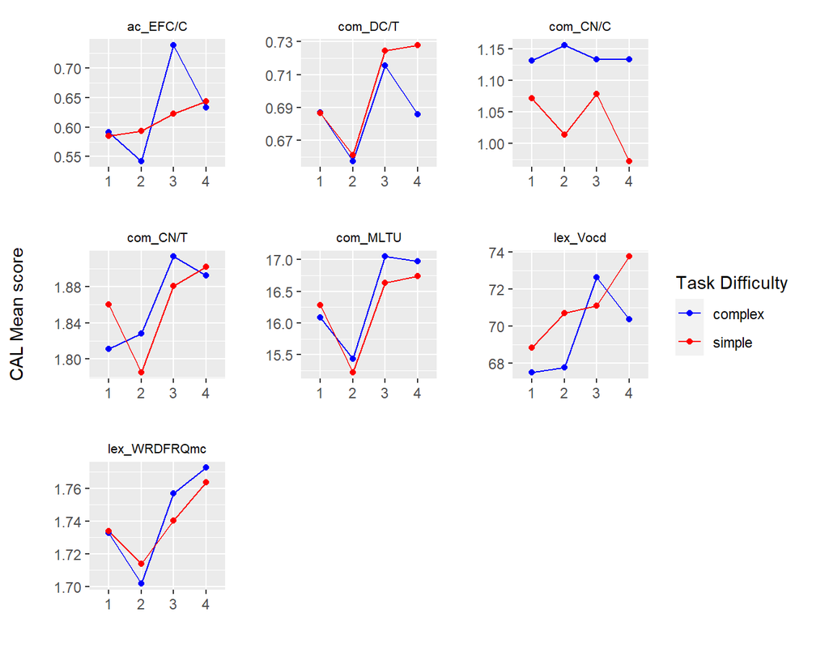

Figure 2. The impact of task repetition on CAL measures moderated by task difficulty

# 5 RQ3: To what extent is that impact moderated by the level of task motivation for simple and complex tasks?

The impact of task repetition on CAL measures moderated by task motivation for simple and complex tasks

row no.

CAL Measure

task_motive

time

order

task_dif

Mean

SE

Lower

Upper

t

p-value

Sig.

1

ac_EFC/C

1.700

1

c2s

complex

0.427

0.093

0.261

0.612

-0.771

0.441

2

ac_EFC/C

2.900

1

c2s

complex

0.524

0.050

0.427

0.620

0.489

0.625

3

ac_EFC/C

4.100

1

c2s

complex

0.619

0.016

0.587

0.651

7.048

0.000

***

4

ac_EFC/C

1.700

2

s2c

complex

0.301

0.088

0.160

0.495

-2.013

0.045

5

ac_EFC/C

2.900

2

s2c

complex

0.423

0.056

0.318

0.536

-1.337

0.182

6

ac_EFC/C

4.100

2

s2c

complex

0.556

0.018

0.519

0.591

3.009

0.003

7

ac_EFC/C

1.700

3

c2s

complex

0.636

0.100

0.427

0.803

1.284

0.200

8

ac_EFC/C

2.900

3

c2s

complex

0.712

0.035

0.638

0.776

5.283

0.000

***

9

ac_EFC/C

4.100

3

c2s

complex

0.778

0.024

0.728

0.821

9.192

0.000

***

10

ac_EFC/C

1.700

4

s2c

complex

0.641

0.098

0.435

0.805

1.356

0.176

11

ac_EFC/C

2.900

4

s2c

complex

0.647

0.040

0.565

0.721

3.449

0.001

***

12

ac_EFC/C

4.100

4

s2c

complex

0.653

0.026

0.599

0.702

5.452

0.000

***

13

ac_EFC/C

1.700

1

s2c

simple

0.566

0.020

0.527

0.605

3.303

0.001

14

ac_EFC/C

2.900

1

s2c

simple

0.572

0.024

0.525

0.618

3.019

0.003

15

ac_EFC/C

4.100

1

s2c

simple

0.578

0.051

0.476

0.673

1.511

0.132

16

ac_EFC/C

1.700

2

c2s

simple

0.579

0.025

0.528

0.627

3.068

0.002

17

ac_EFC/C

2.900

2

c2s

simple

0.585

0.019

0.547

0.622

4.346

0.000

***

18

ac_EFC/C

4.100

2

c2s

simple

0.591

0.045

0.501

0.675

1.985

0.048

19

ac_EFC/C

1.700

3

s2c

simple

0.582

0.022

0.538

0.626

3.611

0.000

***

20

ac_EFC/C

2.900

3

s2c

simple

0.544

0.088

0.372

0.706

0.491

0.624

21

ac_EFC/C

4.100

3

s2c

simple

0.504

0.162

0.222

0.784

0.026

0.979

22

ac_EFC/C

1.700

4

c2s

simple

0.604

0.019

0.566

0.641

5.264

0.000

***

23

ac_EFC/C

2.900

4

c2s

simple

0.569

0.071

0.428

0.701

0.962

0.336

24

ac_EFC/C

4.100

4

c2s

simple

0.534

0.130

0.291

0.762

0.263

0.792

25

com_DC/T

1.700

1

c2s

complex

0.542

0.114

0.325

0.744

0.370

0.711

26

com_DC/T

2.900

1

c2s

complex

0.623

0.057

0.507

0.727

2.078

0.038

27

com_DC/T

4.100

1

c2s

complex

0.697

0.017

0.663

0.730

10.346

0.000

***

28

com_DC/T

1.700

2

s2c

complex

0.358

0.112

0.176

0.592

-1.203

0.230

29

com_DC/T

2.900

2

s2c

complex

0.503

0.068

0.373

0.633

0.051

0.960

30

com_DC/T

4.100

2

s2c

complex

0.649

0.020

0.608

0.687

6.979

0.000

***

31

com_DC/T

1.700

3

c2s

complex

0.734

0.098

0.508

0.881

2.032

0.043

32

com_DC/T

2.900

3

c2s

complex

0.726

0.040

0.641

0.797

4.854

0.000

***

33

com_DC/T

4.100

3

c2s

complex

0.718

0.030

0.655

0.774

6.254

0.000

***

34

com_DC/T

1.700

4

s2c

complex

0.805

0.082

0.596

0.920

2.706

0.007

35

com_DC/T

2.900

4

s2c

complex

0.740

0.042

0.650

0.814

4.819

0.000

***

36

com_DC/T

4.100

4

s2c

complex

0.664

0.030

0.602

0.721

5.030

0.000

***

37

com_DC/T

1.700

1

s2c

simple

0.726

0.024

0.676

0.770

8.082

0.000

***

38

com_DC/T

2.900

1

s2c

simple

0.622

0.029

0.564

0.677

4.077

0.000

***

39

com_DC/T

4.100

1

s2c

simple

0.506

0.069

0.374

0.637

0.087

0.931

40

com_DC/T

1.700

2

c2s

simple

0.622

0.031

0.559

0.681

3.772

0.000

***

41

com_DC/T

2.900

2

c2s

simple

0.678

0.022

0.633

0.719

7.341

0.000

***

42

com_DC/T

4.100

2

c2s

simple

0.728

0.047

0.627

0.810

4.165

0.000

***

43

com_DC/T

1.700

3

s2c

simple

0.724

0.026

0.671

0.772

7.546

0.000

***

44

com_DC/T

2.900

3

s2c

simple

0.778

0.088

0.564

0.905

2.475

0.014

45

com_DC/T

4.100

3

s2c

simple

0.824

0.134

0.433

0.966

1.675

0.095

.

46

com_DC/T

1.700

4

c2s

simple

0.711

0.023

0.664

0.754

8.056

0.000

***

47

com_DC/T

2.900

4

c2s

simple

0.682

0.089

0.488

0.828

1.853

0.065

.

48

com_DC/T

4.100

4

c2s

simple

0.651

0.169

0.302

0.889

0.837

0.403

49

com_CN/C

1.700

1

c2s

complex

1.188

0.196

0.799

1.577

6.065

0.000

***

50

com_CN/C

2.900

1

c2s

complex

1.144

0.103

0.940

1.349

11.093

0.000

***

51

com_CN/C

4.100

1

c2s

complex

1.101

0.034

1.033

1.169

31.984

0.000

***

52

com_CN/C

1.700

2

s2c

complex

1.119

0.220

0.681

1.556

5.075

0.000

***

53

com_CN/C

2.900

2

s2c

complex

1.120

0.122

0.877

1.363

9.146

0.000

***

54

com_CN/C

4.100

2

s2c

complex

1.121

0.039

1.044

1.197

28.980

0.000

***

55

com_CN/C

1.700

3

c2s

complex

1.028

0.205

0.622

1.435

5.021

0.000

***

56

com_CN/C

2.900

3

c2s

complex

1.085

0.082

0.923

1.247

13.279

0.000

***

57

com_CN/C

4.100

3

c2s

complex

1.142

0.063

1.016

1.267

18.054

0.000

***

58

com_CN/C

1.700

4

s2c

complex

1.089

0.222

0.649

1.530

4.909

0.000

***

59

com_CN/C

2.900

4

s2c

complex

1.106

0.091

0.925

1.286

12.150

0.000

***

60

com_CN/C

4.100

4

s2c

complex

1.122

0.060

1.004

1.241

18.757

0.000

***

61

com_CN/C

1.700

1

s2c

simple

1.180

0.043

1.095

1.266

27.410

0.000

***

62

com_CN/C

2.900

1

s2c

simple

0.961

0.051

0.859

1.062

18.785

0.000

***

63

com_CN/C

4.100

1

s2c

simple

0.741

0.111

0.521

0.960

6.701

0.000

***

64

com_CN/C

1.700

2

c2s

simple

0.989

0.052

0.886

1.093

18.998

0.000

***

65

com_CN/C

2.900

2

c2s

simple

1.046

0.042

0.963

1.128

25.174

0.000

***

66

com_CN/C

4.100

2

c2s

simple

1.102

0.097

0.910

1.294

11.394

0.000

***

67

com_CN/C

1.700

3

s2c

simple

1.104

0.048

1.008

1.200

22.913

0.000

***

68

com_CN/C

2.900

3

s2c

simple

1.032

0.189

0.656

1.408

5.446

0.000

***

69

com_CN/C

4.100

3

s2c

simple

0.959

0.344

0.277

1.642

2.790

0.006

70

com_CN/C

1.700

4

c2s

simple

1.053

0.042

0.970

1.137

24.930

0.000

***

71

com_CN/C

2.900

4

c2s

simple

1.288

0.154

0.983

1.593

8.374

0.000

***

72

com_CN/C

4.100

4

c2s

simple

1.522

0.277

0.973

2.071

5.499

0.000

***

73

com_CN/T

1.700

1

c2s

complex

1.859

0.149

1.564

2.155

12.491

0.000

***

74

com_CN/T

2.900

1

c2s

complex

1.832

0.078

1.678

1.986

23.603

0.000

***

75

com_CN/T

4.100

1

c2s

complex

1.804

0.027

1.751

1.857

67.741

0.000

***

76

com_CN/T

1.700

2

s2c

complex

1.702

0.094

1.517

1.888

18.181

0.000

***

77

com_CN/T

2.900

2

s2c

complex

1.758

0.051

1.656

1.860

34.238

0.000

***

78

com_CN/T

4.100

2

s2c

complex

1.813

0.016

1.782

1.845

114.026

0.000

***

79

com_CN/T

1.700

3

c2s

complex

1.956

0.042

1.873

2.039

47.006

0.000

***

80

com_CN/T

2.900

3

c2s

complex

1.927

0.017

1.893

1.960

114.309

0.000

***

81

com_CN/T

4.100

3

c2s

complex

1.897

0.013

1.870

1.924

140.900

0.000

***

82

com_CN/T

1.700

4

s2c

complex

1.779

0.057

1.666

1.891

31.466

0.000

***

83

com_CN/T

2.900

4

s2c

complex

1.845

0.023

1.799

1.892

79.513

0.000

***

84

com_CN/T

4.100

4

s2c

complex

1.912

0.015

1.882

1.943

123.875

0.000

***

85

com_CN/T

1.700

1

s2c

simple

1.898

0.042

1.815

1.982

45.162

0.000

***

86

com_CN/T

2.900

1

s2c

simple

1.812

0.051

1.710

1.913

35.520

0.000

***

87

com_CN/T

4.100

1

s2c

simple

1.725

0.110

1.507

1.943

15.720

0.000

***

88

com_CN/T

1.700

2

c2s

simple

1.779

0.027

1.726

1.832

66.792

0.000

***

89

com_CN/T

2.900

2

c2s

simple

1.794

0.021

1.753

1.835

86.698

0.000

***

90

com_CN/T

4.100

2

c2s

simple

1.809

0.049

1.712

1.907

36.845

0.000

***

91

com_CN/T

1.700

3

s2c

simple

1.889

0.013

1.864

1.915

149.207

0.000

***

92

com_CN/T

2.900

3

s2c

simple

1.890

0.047

1.796

1.984

39.851

0.000

***

93

com_CN/T

4.100

3

s2c

simple

1.891

0.086

1.721

2.062

22.012

0.000

***

94

com_CN/T

1.700

4

c2s

simple

1.893

0.012

1.868

1.917

154.275

0.000

***

95

com_CN/T

2.900

4

c2s

simple

1.806

0.042

1.722

1.890

42.529

0.000

***

96

com_CN/T

4.100

4

c2s

simple

1.719

0.076

1.568

1.870

22.645

0.000

***

97

com_MLTU

1.700

1

c2s

complex

15.641

1.216

13.229

18.054

12.866

0.000

***

98

com_MLTU

2.900

1

c2s

complex

15.923

0.639

14.654

17.191

24.909

0.000

***

99

com_MLTU

4.100

1

c2s

complex

16.204

0.216

15.775

16.633

74.892

0.000

***

100

com_MLTU

1.700

2

s2c

complex

15.047

1.350

12.367

17.727

11.142

0.000

***

101

com_MLTU

2.900

2

s2c

complex

15.296

0.747

13.815

16.778

20.488

0.000

***

102

com_MLTU

4.100

2

s2c

complex

15.546

0.234

15.082

16.010

66.470

0.000

***

103

com_MLTU

1.700

3

c2s

complex

18.515

0.948

16.633

20.396

19.526

0.000

***

104

com_MLTU

2.900

3

c2s

complex

17.632

0.379

16.879

18.385

46.485

0.000

***

105

com_MLTU

4.100

3

c2s

complex

16.749

0.296

16.161

17.336

56.570

0.000

***

106

com_MLTU

1.700

4

s2c

complex

17.643

1.167

15.326

19.959

15.112

0.000

***

107

com_MLTU

2.900

4

s2c

complex

17.281

0.480

16.329

18.232

36.022

0.000

***

108

com_MLTU

4.100

4

s2c

complex

16.918

0.317

16.290

17.547

53.403

0.000

***

109

com_MLTU

1.700

1

s2c

simple

16.067

0.287

15.498

16.637

55.944

0.000

***

110

com_MLTU

2.900

1

s2c

simple

16.405

0.342

15.727

17.083

48.010

0.000

***

111

com_MLTU

4.100

1

s2c

simple

16.742

0.734

15.286

18.198

22.818

0.000

***

112

com_MLTU

1.700

2

c2s

simple

14.885

0.341

14.209

15.562

43.645

0.000

***

113

com_MLTU

2.900

2

c2s

simple

15.354

0.270

14.818

15.889

56.885

0.000

***

114

com_MLTU

4.100

2

c2s

simple

15.822

0.635

14.563

17.082

24.926

0.000

***

115

com_MLTU

1.700

3

s2c

simple

16.418

0.248

15.925

16.910

66.090

0.000

***

116

com_MLTU

2.900

3

s2c

simple

16.057

0.968

14.136

17.978

16.582

0.000

***

117

com_MLTU

4.100

3

s2c

simple

15.697

1.758

12.209

19.184

8.930

0.000

***

118

com_MLTU

1.700

4

c2s

simple

16.712

0.239

16.238

17.185

70.000

0.000

***

119

com_MLTU

2.900

4

c2s

simple

17.281

0.855

15.586

18.977

20.223

0.000

***

120

com_MLTU

4.100

4

c2s

simple

17.851

1.534

14.807

20.895

11.636

0.000

***

121

lex_Vocd

1.700

1

c2s

complex

68.925

6.416

56.194

81.656

10.742

0.000

***

122

lex_Vocd

2.900

1

c2s

complex

68.730

3.379

62.025

75.436

20.339

0.000

***

123

lex_Vocd

4.100

1

c2s

complex

68.536

1.127

66.299

70.772

60.808

0.000

***

124

lex_Vocd

1.700

2

s2c

complex

64.539

7.224

50.206

78.873

8.935

0.000

***

125

lex_Vocd

2.900

2

s2c

complex

66.593

4.011

58.634

74.552

16.601

0.000

***

126

lex_Vocd

4.100

2

s2c

complex

68.646

1.266

66.134

71.159

54.217

0.000

***

127

lex_Vocd

1.700

3

c2s

complex

78.658

6.711

65.343

91.973

11.721

0.000

***

128

lex_Vocd

2.900

3

c2s

complex

75.204

2.677

69.893

80.516

28.095

0.000

***

129

lex_Vocd

4.100

3

c2s

complex

71.751

2.071

67.641

75.861

34.640

0.000

***

130

lex_Vocd

1.700

4

s2c

complex

64.761

7.271

50.333

79.188

8.907

0.000

***

131

lex_Vocd

2.900

4

s2c

complex

68.574

2.982

62.656

74.491

22.995

0.000

***

132

lex_Vocd

4.100

4

s2c

complex

72.387

1.960

68.497

76.276

36.930

0.000

***

133

lex_Vocd

1.700

1

s2c

simple

66.795

1.411

63.995

69.594

47.346

0.000

***

134

lex_Vocd

2.900

1

s2c

simple

70.291

1.675

66.968

73.615

41.964

0.000

***

135

lex_Vocd

4.100

1

s2c

simple

73.788

3.621

66.603

80.973

20.378

0.000

***

136

lex_Vocd

1.700

2

c2s

simple

70.916

1.706

67.532

74.300

41.578

0.000

***

137

lex_Vocd

2.900

2

c2s

simple

69.922

1.361

67.222

72.623

51.374

0.000

***

138

lex_Vocd

4.100

2

c2s

simple

68.928

3.170

62.639

75.218

21.745

0.000

***

139

lex_Vocd

1.700

3

s2c

simple

70.575

1.577

67.446

73.703

44.759

0.000

***

140

lex_Vocd

2.900

3

s2c

simple

74.253

6.207

61.938

86.568

11.964

0.000

***

141

lex_Vocd

4.100

3

s2c

simple

77.931

11.265

55.579

100.284

6.918

0.000

***

142

lex_Vocd

1.700

4

c2s

simple

72.604

1.384

69.857

75.351

52.443

0.000

***

143

lex_Vocd

2.900

4

c2s

simple

72.892

5.040

62.892

82.892

14.463

0.000

***

144

lex_Vocd

4.100

4

c2s

simple

73.181

9.071

55.182

91.179

8.068

0.000

***

145

lex_WRDFRQmc

1.700

1

c2s

complex

1.818

0.093

1.634

2.002

19.638

0.000

***

146

lex_WRDFRQmc

2.900

1

c2s

complex

1.777

0.049

1.681

1.874

36.455

0.000

***

147

lex_WRDFRQmc

4.100

1

c2s

complex

1.737

0.016

1.705

1.769

106.805

0.000

***

148

lex_WRDFRQmc

1.700

2

s2c

complex

1.859

0.104

1.652

2.066

17.838

0.000

***

149

lex_WRDFRQmc

2.900

2

s2c

complex

1.788

0.058

1.673

1.903

30.897

0.000

***

150

lex_WRDFRQmc

4.100

2

s2c

complex

1.717

0.018

1.681

1.754

94.009

0.000

***

151

lex_WRDFRQmc

1.700

3

c2s

complex

1.769

0.097

1.577

1.962

18.274

0.000

***

152

lex_WRDFRQmc

2.900

3

c2s

complex

1.764

0.039

1.687

1.840

45.661

0.000

***

153

lex_WRDFRQmc

4.100

3

c2s

complex

1.758

0.030

1.698

1.817

58.811

0.000

***

154

lex_WRDFRQmc

1.700

4

s2c

complex

1.608

0.105

1.400

1.816

15.325

0.000

***

155

lex_WRDFRQmc

2.900

4

s2c

complex

1.711

0.043

1.625

1.796

39.758

0.000

***

156

lex_WRDFRQmc

4.100

4

s2c

complex

1.814

0.028

1.758

1.870

64.129

0.000

***

157

lex_WRDFRQmc

1.700

1

s2c

simple

1.722

0.020

1.682

1.762

84.597

0.000

***

158

lex_WRDFRQmc

2.900

1

s2c

simple

1.744

0.024

1.696

1.792

72.155

0.000

***

159

lex_WRDFRQmc

4.100

1

s2c

simple

1.766

0.052

1.662

1.869

33.796

0.000

***

160

lex_WRDFRQmc

1.700

2

c2s

simple

1.691

0.025

1.642

1.740

68.712

0.000

***

161

lex_WRDFRQmc

2.900

2

c2s

simple

1.725

0.020

1.686

1.764

87.838

0.000

***

162

lex_WRDFRQmc

4.100

2

c2s

simple

1.759

0.046

1.668

1.850

38.457

0.000

***

163

lex_WRDFRQmc

1.700

3

s2c

simple

1.722

0.023

1.677

1.767

75.696

0.000

***

164

lex_WRDFRQmc

2.900

3

s2c

simple

1.655

0.090

1.477

1.833

18.479

0.000

***

165

lex_WRDFRQmc

4.100

3

s2c

simple

1.588

0.163

1.265

1.910

9.767

0.000

***

166

lex_WRDFRQmc

1.700

4

c2s

simple

1.755

0.020

1.715

1.794

87.848

0.000

***

167

lex_WRDFRQmc

2.900

4

c2s

simple

1.736

0.073

1.591

1.880

23.869

0.000

***

168

lex_WRDFRQmc

4.100

4

c2s

simple

1.717

0.131

1.457

1.976

13.116

0.000

***

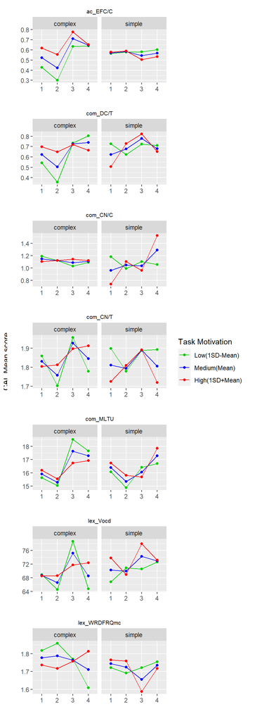

Figure 3. The impact of task repetition on CAL measures moderated by task motivation for simple and complex tasks

# 6 RQ4: To what extent is that impact moderated by the level of time on task for simple and complex tasks?

The impact of task repetition on CAL measures moderated by time on task for simple and complex tasks

row no.

CAL Measure

time_on_task

time

order

task_dif

Mean

SE

Lower

Upper

t

p-value

Sig.

1

ac_EFC/C

28.000

1

c2s

complex

0.513

0.037

0.440

0.585

0.347

0.729

2

ac_EFC/C

32.600

1

c2s

complex

0.567

0.026

0.515

0.617

2.538

0.012

3

ac_EFC/C

37.200

1

c2s

complex

0.619

0.023

0.573

0.663

5.008

0.000

***

4

ac_EFC/C

28.000

2

s2c

complex

0.571

0.044

0.483

0.654

1.589

0.113

5

ac_EFC/C

32.600

2

s2c

complex

0.560

0.030

0.501

0.618

1.990

0.047

6

ac_EFC/C

37.200

2

s2c

complex

0.549

0.025

0.500

0.598

1.981

0.048

7

ac_EFC/C

28.000

3

c2s

complex

0.737

0.031

0.672

0.794

6.422

0.000

***

8

ac_EFC/C

32.600

3

c2s

complex

0.743

0.018

0.706

0.777

11.211

0.000

***

9

ac_EFC/C

37.200

3

c2s

complex

0.748

0.016

0.714

0.779

12.443

0.000

***

10

ac_EFC/C

28.000

4

s2c

complex

0.622

0.036

0.549

0.691

3.235

0.001

11

ac_EFC/C

32.600

4

s2c

complex

0.635

0.020

0.595

0.672

6.549

0.000

***

12

ac_EFC/C

37.200

4

s2c

complex

0.647

0.022

0.603

0.689

6.320

0.000

***

13

ac_EFC/C

28.000

1

s2c

simple

0.577

0.021

0.534

0.618

3.540

0.000

***

14

ac_EFC/C

32.600

1

s2c

simple

0.581

0.020

0.541

0.620

3.958

0.000

***

15

ac_EFC/C

37.200

1

s2c

simple

0.586

0.036

0.514

0.655

2.347

0.019

16

ac_EFC/C

28.000

2

c2s

simple

0.593

0.025

0.544

0.640

3.710

0.000

***

17

ac_EFC/C

32.600

2

c2s

simple

0.591

0.017

0.558

0.623

5.314

0.000

***

18

ac_EFC/C

37.200

2

c2s

simple

0.588

0.029

0.530

0.644

2.971

0.003

19

ac_EFC/C

28.000

3

s2c

simple

0.609

0.025

0.558

0.657

4.199

0.000

***

20

ac_EFC/C

32.600

3

s2c

simple

0.616

0.035

0.544

0.682

3.162

0.002

21

ac_EFC/C

37.200

3

s2c

simple

0.623

0.052

0.516

0.719

2.252

0.025

22

ac_EFC/C

28.000

4

c2s

simple

0.631

0.024

0.583

0.677

5.201

0.000

***

23

ac_EFC/C

32.600

4

c2s

simple

0.641

0.026

0.589

0.690

5.156

0.000

***

24

ac_EFC/C

37.200

4

c2s

simple

0.651

0.037

0.575

0.719

3.829

0.000

***

25

com_DC/T

28.000

1

c2s

complex

0.668

0.041

0.583

0.744

3.759

0.000

***

26

com_DC/T

32.600

1

c2s

complex

0.677

0.029

0.618

0.731

5.584

0.000

***

27

com_DC/T

37.200

1

c2s

complex

0.686

0.026

0.633

0.735

6.466

0.000

***

28

com_DC/T

28.000

2

s2c

complex

0.677

0.048

0.576

0.764

3.348

0.001

***

29

com_DC/T

32.600

2

s2c

complex

0.663

0.034

0.593

0.726

4.454

0.000

***

30

com_DC/T

37.200

2

s2c

complex

0.648

0.029

0.590

0.703

4.812

0.000

***

31

com_DC/T

28.000

3

c2s

complex

0.772

0.034

0.697

0.832

6.245

0.000

***

32

com_DC/T

32.600

3

c2s

complex

0.735

0.022

0.688

0.776

8.865

0.000

***

33

com_DC/T

37.200

3

c2s

complex

0.694

0.022

0.650

0.735

8.029

0.000

***

34

com_DC/T

28.000

4

s2c

complex

0.682

0.042

0.595

0.758

3.970

0.000

***

35

com_DC/T

32.600

4

s2c

complex

0.683

0.023

0.636

0.726

7.253

0.000

***

36

com_DC/T

37.200

4

s2c

complex

0.684

0.026

0.631

0.732

6.495

0.000

***

37

com_DC/T

28.000

1

s2c

simple

0.710

0.025

0.659

0.757

7.399

0.000

***

38

com_DC/T

32.600

1

s2c

simple

0.674

0.025

0.624

0.720

6.517

0.000

***

39

com_DC/T

37.200

1

s2c

simple

0.636

0.046

0.541

0.721

2.791

0.006

40

com_DC/T

28.000

2

c2s

simple

0.667

0.029

0.607

0.721

5.259

0.000

***

41

com_DC/T

32.600

2

c2s

simple

0.662

0.020

0.622

0.700

7.558

0.000

***

42

com_DC/T

37.200

2

c2s

simple

0.658

0.035

0.586

0.723

4.185

0.000

***

43

com_DC/T

28.000

3

s2c

simple

0.732

0.027

0.675

0.782

7.197

0.000

***

44

com_DC/T

32.600

3

s2c

simple

0.733

0.040

0.648

0.803

4.973

0.000

***

45

com_DC/T

37.200

3

s2c

simple

0.734

0.060

0.600

0.835

3.279

0.001

46

com_DC/T

28.000

4

c2s

simple

0.723

0.028

0.665

0.774

6.905

0.000

***

47

com_DC/T

32.600

4

c2s

simple

0.747

0.029

0.685

0.800

6.997

0.000

***

48

com_DC/T

37.200

4

c2s

simple

0.769

0.040

0.682

0.839

5.341

0.000

***

49

com_CN/C

28.000

1

c2s

complex

1.153

0.077

1.000

1.307

14.897

0.000

***

50

com_CN/C

32.600

1

c2s

complex

1.128

0.054

1.021

1.236

20.796

0.000

***

51

com_CN/C

37.200

1

c2s

complex

1.103

0.049

1.005

1.201

22.390

0.000

***

52

com_CN/C

28.000

2

s2c

complex

1.169

0.093

0.984

1.355

12.508

0.000

***

53

com_CN/C

32.600

2

s2c

complex

1.149

0.063

1.024

1.273

18.335

0.000

***

54

com_CN/C

37.200

2

s2c

complex

1.128

0.052

1.025

1.232

21.632

0.000

***

55

com_CN/C

28.000

3

c2s

complex

1.130

0.077

0.977

1.284

14.622

0.000

***

56

com_CN/C

32.600

3

c2s

complex

1.123

0.046

1.032

1.214

24.567

0.000

***

57

com_CN/C

37.200

3

c2s

complex

1.116

0.042

1.032

1.200

26.345

0.000

***

58

com_CN/C

28.000

4

s2c

complex

1.107

0.080

0.947

1.266

13.794

0.000

***

59

com_CN/C

32.600

4

s2c

complex

1.118

0.044

1.031

1.205

25.404

0.000

***

60

com_CN/C

37.200

4

s2c

complex

1.130

0.049

1.032

1.228

22.870

0.000

***

61

com_CN/C

28.000

1

s2c

simple

1.085

0.046

0.993

1.177

23.352

0.000

***

62

com_CN/C

32.600

1

s2c

simple

1.083

0.044

0.995

1.171

24.491

0.000

***

63

com_CN/C

37.200

1

s2c

simple

1.082

0.080

0.923

1.240

13.577

0.000

***

64

com_CN/C

28.000

2

c2s

simple

1.128

0.054

1.021

1.234

21.019

0.000

***

65

com_CN/C

32.600

2

c2s

simple

1.000

0.036

0.928

1.072

27.548

0.000

***

66

com_CN/C

37.200

2

c2s

simple

0.872

0.064

0.746

0.999

13.675

0.000

***

67

com_CN/C

28.000

3

s2c

simple

1.115

0.054

1.007

1.223

20.527

0.000

***

68

com_CN/C

32.600

3

s2c

simple

1.133

0.078

0.979

1.287

14.618

0.000

***

69

com_CN/C

37.200

3

s2c

simple

1.151

0.117

0.919

1.383

9.844

0.000

***

70

com_CN/C

28.000

4

c2s

simple

0.998

0.054

0.890

1.105

18.434

0.000

***

71

com_CN/C

32.600

4

c2s

simple

0.981

0.059

0.864

1.098

16.633

0.000

***

72

com_CN/C

37.200

4

c2s

simple

0.965

0.084

0.798

1.133

11.432

0.000

***

73

com_CN/T

28.000

1

c2s

complex

1.807

0.065

1.678

1.936

27.787

0.000

***

74

com_CN/T

32.600

1

c2s

complex

1.815

0.041

1.733

1.896

44.162

0.000

***

75

com_CN/T

37.200

1

c2s

complex

1.822

0.030

1.763

1.882

60.823

0.000

***

76

com_CN/T

28.000

2

s2c

complex

1.807

0.043

1.723

1.891

42.501

0.000

***

77

com_CN/T

32.600

2

s2c

complex

1.823

0.028

1.767

1.878

65.088

0.000

***

78

com_CN/T

37.200

2

s2c

complex

1.839

0.021

1.797

1.881

87.007

0.000

***

79

com_CN/T

28.000

3

c2s

complex

1.897

0.018

1.860

1.933

102.959

0.000

***

80

com_CN/T

32.600

3

c2s

complex

1.911

0.012

1.887

1.935

156.356

0.000

***

81

com_CN/T

37.200

3

c2s

complex

1.925

0.011

1.904

1.947

175.091

0.000

***

82

com_CN/T

28.000

4

s2c

complex

1.911

0.023

1.865

1.957

82.428

0.000

***

83

com_CN/T

32.600

4

s2c

complex

1.902

0.014

1.874

1.929

137.731

0.000

***

84

com_CN/T

37.200

4

s2c

complex

1.892

0.014

1.865

1.920

137.842

0.000

***

85

com_CN/T

28.000

1

s2c

simple

1.910

0.049

1.813

2.006

39.316

0.000

***

86

com_CN/T

32.600

1

s2c

simple

1.840

0.036

1.770

1.911

51.782

0.000

***

87

com_CN/T

37.200

1

s2c

simple

1.771

0.067

1.638

1.904

26.445

0.000

***

88

com_CN/T

28.000

2

c2s

simple

1.797

0.029

1.739

1.855

61.811

0.000

***

89

com_CN/T

32.600

2

c2s

simple

1.788

0.017

1.754

1.822

104.049

0.000

***

90

com_CN/T

37.200

2

c2s

simple

1.779

0.028

1.724

1.834

64.200

0.000

***

91

com_CN/T

28.000

3

s2c

simple

1.869

0.019

1.832

1.907

98.451

0.000

***

92

com_CN/T

32.600

3

s2c

simple

1.884

0.023

1.839

1.929

83.144

0.000

***

93

com_CN/T

37.200

3

s2c

simple

1.899

0.031

1.838

1.960

61.588

0.000

***

94

com_CN/T

28.000

4

c2s

simple

1.882

0.020

1.842

1.922

93.165

0.000

***

95

com_CN/T

32.600

4

c2s

simple

1.909

0.020

1.869

1.949

94.712

0.000

***

96

com_CN/T

37.200

4

c2s

simple

1.936

0.026

1.884

1.987

74.435

0.000

***

97

com_MLTU

28.000

1

c2s

complex

16.300

0.494

15.319

17.281

32.967

0.000

***

98

com_MLTU

32.600

1

c2s

complex

16.172

0.341

15.495

16.849

47.368

0.000

***

99

com_MLTU

37.200

1

c2s

complex

16.044

0.296

15.458

16.631

54.269

0.000

***

100

com_MLTU

28.000

2

s2c

complex

15.323

0.580

14.171

16.475

26.400

0.000

***

101

com_MLTU

32.600

2

s2c

complex

15.379

0.386

14.614

16.144

39.883

0.000

***

102

com_MLTU

37.200

2

s2c

complex

15.435

0.312

14.817

16.053

49.544

0.000

***

103

com_MLTU

28.000

3

c2s

complex

17.361

0.379

16.609

18.112

45.846

0.000

***

104

com_MLTU

32.600

3

c2s

complex

17.161

0.231

16.702

17.620

74.131

0.000

***

105

com_MLTU

37.200

3

c2s

complex

16.962

0.208

16.550

17.373

81.737

0.000

***

106

com_MLTU

28.000

4

s2c

complex

16.672

0.424

15.830

17.513

39.298

0.000

***

107

com_MLTU

32.600

4

s2c

complex

16.870

0.240

16.394

17.346

70.365

0.000

***

108

com_MLTU

37.200

4

s2c

complex

17.068

0.254

16.563

17.573

67.079

0.000

***

109

com_MLTU

28.000

1

s2c

simple

16.551

0.310

15.936

17.166

53.394

0.000

***

110

com_MLTU

32.600

1

s2c

simple

16.128

0.279

15.574

16.682

57.766

0.000

***

111

com_MLTU

37.200

1

s2c

simple

15.706

0.504

14.707

16.705

31.190

0.000

***

112

com_MLTU

28.000

2

c2s

simple

15.303

0.356

14.597

16.008

43.045

0.000

***

113

com_MLTU

32.600

2

c2s

simple

15.229

0.228

14.777

15.682

66.767

0.000

***

114

com_MLTU

37.200

2

c2s

simple

15.156

0.395

14.373

15.939

38.409

0.000

***

115

com_MLTU

28.000

3

s2c

simple

16.623

0.303

16.022

17.225

54.853

0.000

***

116

com_MLTU

32.600

3

s2c

simple

16.432

0.402

15.635

17.229

40.905

0.000

***

117

com_MLTU

37.200

3

s2c

simple

16.240

0.591

15.068

17.413

27.488

0.000

***

118

com_MLTU

28.000

4

c2s

simple

16.519

0.315

15.895

17.143

52.492

0.000

***

119

com_MLTU

32.600

4

c2s

simple

17.039

0.329

16.386

17.691

51.832

0.000

***

120

com_MLTU

37.200

4

c2s

simple

17.558

0.454

16.657

18.460

38.652

0.000

***

121

lex_Vocd

28.000

1

c2s

complex

63.827

2.492

58.881

68.772

25.608

0.000

***

122

lex_Vocd

32.600

1

c2s

complex

65.999

1.747

62.534

69.465

37.789

0.000

***

123

lex_Vocd

37.200

1

c2s

complex

68.172

1.586

65.025

71.319

42.985

0.000

***

124

lex_Vocd

28.000

2

s2c

complex

66.029

3.009

60.059

72.000

21.945

0.000

***

125

lex_Vocd

32.600

2

s2c

complex

66.981

2.017

62.979

70.983

33.209

0.000

***

126

lex_Vocd

37.200

2

s2c

complex

67.933

1.679

64.601

71.264

40.456

0.000

***

127

lex_Vocd

28.000

3

c2s

complex

72.911

2.489

67.974

77.849

29.299

0.000

***

128

lex_Vocd

32.600

3

c2s

complex

72.739

1.472

69.819

75.659

49.423

0.000

***

129

lex_Vocd

37.200

3

c2s

complex

72.567

1.364

69.861

75.273

53.211

0.000

***

130

lex_Vocd

28.000

4

s2c

complex

70.016

2.583

64.892

75.141

27.110

0.000

***

131

lex_Vocd

32.600

4

s2c

complex

70.216

1.417

67.405

73.028

49.557

0.000

***

132

lex_Vocd

37.200

4

s2c

complex

70.417

1.590

67.262

73.572

44.288

0.000

***

133

lex_Vocd

28.000

1

s2c

simple

69.913

1.495

66.946

72.880

46.755

0.000

***

134

lex_Vocd

32.600

1

s2c

simple

68.073

1.424

65.248

70.898

47.814

0.000

***

135

lex_Vocd

37.200

1

s2c

simple

66.233

2.565

61.144

71.321

25.827

0.000

***

136

lex_Vocd

28.000

2

c2s

simple

72.870

1.727

69.443

76.297

42.191

0.000

***

137

lex_Vocd

32.600

2

c2s

simple

70.382

1.168

68.064

72.701

60.236

0.000

***

138

lex_Vocd

37.200

2

c2s

simple

67.895

2.053

63.821

71.968

33.071

0.000

***

139

lex_Vocd

28.000

3

s2c

simple

71.065

1.748

67.596

74.534

40.649

0.000

***

140

lex_Vocd

32.600

3

s2c

simple

70.671

2.495

65.720

75.622

28.321

0.000

***

141

lex_Vocd

37.200

3

s2c

simple

70.277

3.765

62.806

77.749

18.664

0.000

***

142

lex_Vocd

28.000

4

c2s

simple

73.313

1.742

69.856

76.770

42.081

0.000

***

143

lex_Vocd

32.600

4

c2s

simple

74.951

1.899

71.182

78.720

39.459

0.000

***

144

lex_Vocd

37.200

4

c2s

simple

76.588

2.718

71.195

81.981

28.178

0.000

***

145

lex_WRDFRQmc

28.000

1

c2s

complex

1.731

0.036

1.658

1.803

47.436

0.000

***

146

lex_WRDFRQmc

32.600

1

c2s

complex

1.732

0.026

1.681

1.783

67.760

0.000

***

147

lex_WRDFRQmc

37.200

1

c2s

complex

1.734

0.023

1.688

1.780

74.690

0.000

***

148

lex_WRDFRQmc

28.000

2

s2c

complex

1.711

0.044

1.624

1.799

38.858

0.000

***

149

lex_WRDFRQmc

32.600

2

s2c

complex

1.706

0.030

1.647

1.765

57.792

0.000

***

150

lex_WRDFRQmc

37.200

2

s2c

complex

1.701

0.025

1.652

1.750

69.204

0.000

***

151

lex_WRDFRQmc

28.000

3

c2s

complex

1.763

0.036

1.690

1.835

48.396

0.000

***

152

lex_WRDFRQmc

32.600

3

c2s

complex

1.759

0.022

1.716

1.802

81.664

0.000

***

153

lex_WRDFRQmc

37.200

3

c2s

complex

1.756

0.020

1.716

1.795

87.951

0.000

***

154

lex_WRDFRQmc

28.000

4

s2c

complex

1.746

0.038

1.671

1.821

46.179

0.000

***

155

lex_WRDFRQmc

32.600

4

s2c

complex

1.765

0.021

1.724

1.806

85.121

0.000

***

156

lex_WRDFRQmc

37.200

4

s2c

complex

1.785

0.023

1.739

1.831

76.700

0.000

***

157

lex_WRDFRQmc

28.000

1

s2c

simple

1.749

0.022

1.706

1.793

79.925

0.000

***

158

lex_WRDFRQmc

32.600

1

s2c

simple

1.721

0.021

1.680

1.763

82.598

0.000

***

159

lex_WRDFRQmc

37.200

1

s2c

simple

1.693

0.038

1.619

1.768

45.107

0.000

***

160

lex_WRDFRQmc

28.000

2

c2s

simple

1.714

0.025

1.664

1.764

67.790

0.000

***

161

lex_WRDFRQmc

32.600

2

c2s

simple

1.713

0.017

1.679

1.747

100.190

0.000

***

162

lex_WRDFRQmc

37.200

2

c2s

simple

1.713

0.030

1.654

1.773

57.014

0.000

***

163

lex_WRDFRQmc

28.000

3

s2c

simple

1.741

0.026

1.690

1.792

68.038

0.000

***

164

lex_WRDFRQmc

32.600

3

s2c

simple

1.749

0.037

1.676

1.821

47.887

0.000

***

165

lex_WRDFRQmc

37.200

3

s2c

simple

1.757

0.055

1.648

1.866

31.879

0.000

***

166

lex_WRDFRQmc

28.000

4

c2s

simple

1.760

0.025

1.710

1.811

69.038

0.000

***

167

lex_WRDFRQmc

32.600

4

c2s

simple

1.767

0.028

1.711

1.822

63.545

0.000

***

168

lex_WRDFRQmc

37.200

4

c2s

simple

1.773

0.040

1.694

1.852

44.564

0.000

***

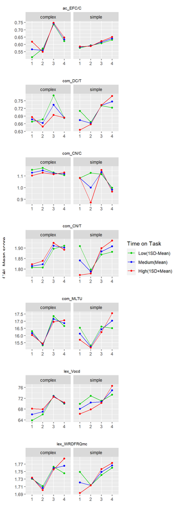

# 7 RQ5: To what extent is that impact moderated by the writing length for simple and complex tasks?

The impact of task repetition on CAL measures moderated by writing length for simple and complex tasks

row no.

CAL Measure

length_writing

time

order

task_dif

Mean

SE

Lower

Upper

t

p-value

Sig.

1

ac_EFC/C

337.300

1

c2s

complex

0.578

0.025

0.529

0.626

3.109

0.002

2

ac_EFC/C

385.100

1

c2s

complex

0.607

0.025

0.558

0.655

4.245

0.000

***

3

ac_EFC/C

433.000

1

c2s

complex

0.636

0.035

0.564

0.702

3.667

0.000

***

4

ac_EFC/C

337.300

2

s2c

complex

0.556

0.027

0.502

0.609

2.034

0.043

5

ac_EFC/C

385.100

2

s2c

complex

0.536

0.026

0.484

0.588

1.364

0.173

6

ac_EFC/C

433.000

2

s2c

complex

0.516

0.038

0.442

0.589

0.426

0.670

7

ac_EFC/C

337.300

3

c2s

complex

0.729

0.024

0.680

0.774

8.174

0.000

***

8

ac_EFC/C

385.100

3

c2s

complex

0.739

0.016

0.706

0.769

12.359

0.000

***

9

ac_EFC/C

433.000

3

c2s

complex

0.748

0.018

0.711

0.782

11.257

0.000

***

10

ac_EFC/C

337.300

4

s2c

complex

0.618

0.028

0.562

0.671

4.070

0.000

***

11

ac_EFC/C

385.100

4

s2c

complex

0.634

0.018

0.598

0.668

7.099

0.000

***

12

ac_EFC/C

433.000

4

s2c

complex

0.649

0.024

0.600

0.696

5.729

0.000

***

13

ac_EFC/C

337.300

1

s2c

simple

0.584

0.023

0.538

0.628

3.561

0.000

***

14

ac_EFC/C

385.100

1

s2c

simple

0.583

0.018

0.547

0.618

4.528

0.000

***

15

ac_EFC/C

433.000

1

s2c

simple

0.583

0.023

0.537

0.628

3.518

0.000

***

16

ac_EFC/C

337.300

2

c2s

simple

0.587

0.019

0.548

0.624

4.377

0.000

***

17

ac_EFC/C

385.100

2

c2s

simple

0.595

0.018

0.560

0.629

5.234

0.000

***

18

ac_EFC/C

433.000

2

c2s

simple

0.603

0.029

0.544

0.659

3.405

0.001

***

19

ac_EFC/C

337.300

3

s2c

simple

0.626

0.035

0.556

0.691

3.487

0.001

***

20

ac_EFC/C

385.100

3

s2c

simple

0.622

0.027

0.568

0.674

4.315

0.000

***

21

ac_EFC/C

433.000

3

s2c

simple

0.619

0.026

0.567

0.668

4.455

0.000

***

22

ac_EFC/C

337.300

4

c2s

simple

0.657

0.029

0.597

0.712

4.992

0.000

***

23

ac_EFC/C

385.100

4

c2s

simple

0.642

0.024

0.594

0.687

5.642

0.000

***

24

ac_EFC/C

433.000

4

c2s

simple

0.626

0.028

0.569

0.680

4.264

0.000

***

25

com_DC/T

337.300

1

c2s

complex

0.696

0.027

0.641

0.747

6.468

0.000

***

26

com_DC/T

385.100

1

c2s

complex

0.679

0.029

0.620

0.733

5.658

0.000

***

27

com_DC/T

433.000

1

c2s

complex

0.662

0.044

0.571

0.742

3.431

0.001

***

28

com_DC/T

337.300

2

s2c

complex

0.668

0.031

0.605

0.725

5.059

0.000

***

29

com_DC/T

385.100

2

s2c

complex

0.649

0.032

0.585

0.708

4.434

0.000

***

30

com_DC/T

433.000

2

s2c

complex

0.629

0.046

0.536

0.714

2.698

0.007

31

com_DC/T

337.300

3

c2s

complex

0.704

0.028

0.647

0.756

6.467

0.000

***

32

com_DC/T

385.100

3

c2s

complex

0.714

0.020

0.673

0.752

9.300

0.000

***

33

com_DC/T

433.000

3

c2s

complex

0.724

0.023

0.677

0.767

8.377

0.000

***

34

com_DC/T

337.300

4

s2c

complex

0.665

0.031

0.601

0.723

4.868

0.000

***

35

com_DC/T

385.100

4

s2c

complex

0.685

0.021

0.642

0.724

8.064

0.000

***

36

com_DC/T

433.000

4

s2c

complex

0.704

0.029

0.643

0.758

6.186

0.000

***

37

com_DC/T

337.300

1

s2c

simple

0.686

0.027

0.630

0.737

6.198

0.000

***

38

com_DC/T

385.100

1

s2c

simple

0.686

0.022

0.642

0.727

7.763

0.000

***

39

com_DC/T

433.000

1

s2c

simple

0.687

0.029

0.626

0.741

5.760

0.000

***

40

com_DC/T

337.300

2

c2s

simple

0.638

0.023

0.592

0.682

5.743

0.000

***

41

com_DC/T

385.100

2

c2s

simple

0.674

0.022

0.630

0.715

7.314

0.000

***

42

com_DC/T

433.000

2

c2s

simple

0.708

0.035

0.635

0.771

5.273

0.000

***

43

com_DC/T

337.300

3

s2c

simple

0.703

0.042

0.614

0.779

4.270

0.000

***

44

com_DC/T

385.100

3

s2c

simple

0.716

0.031

0.650

0.773

5.981

0.000

***

45

com_DC/T

433.000

3

s2c

simple

0.728

0.029

0.667

0.782

6.655

0.000

***

46

com_DC/T

337.300

4

c2s

simple

0.755

0.033

0.685

0.814

6.314

0.000

***

47

com_DC/T

385.100

4

c2s

simple

0.730

0.027

0.673

0.780

7.149

0.000

***

48

com_DC/T

433.000

4

c2s

simple

0.702

0.036

0.628

0.767

5.036

0.000

***

49

com_CN/C

337.300

1

c2s

complex

1.131

0.053

1.026

1.236

21.358

0.000

***

50

com_CN/C

385.100

1

c2s

complex

1.125

0.053

1.020

1.230

21.205

0.000

***

51

com_CN/C

433.000

1

c2s

complex

1.119

0.078

0.964

1.275

14.286

0.000

***

52

com_CN/C

337.300

2

s2c

complex

1.151

0.058

1.036

1.266

19.824

0.000

***

53

com_CN/C

385.100

2

s2c

complex

1.153

0.056

1.042

1.264

20.655

0.000

***

54

com_CN/C

433.000

2

s2c

complex

1.155

0.079

0.998

1.313

14.574

0.000

***

55

com_CN/C

337.300

3

c2s

complex

1.157

0.056

1.046

1.268

20.688

0.000

***

56

com_CN/C

385.100

3

c2s

complex

1.141

0.041

1.061

1.222

28.117

0.000

***

57

com_CN/C

433.000

3

c2s

complex

1.126

0.045

1.036

1.215

24.886

0.000

***

58

com_CN/C

337.300

4

s2c

complex

1.135

0.061

1.014

1.256

18.570

0.000

***

59

com_CN/C

385.100

4

s2c

complex

1.135

0.040

1.056

1.214

28.395

0.000

***

60

com_CN/C

433.000

4

s2c

complex

1.135

0.055

1.026

1.244

20.714

0.000

***

61

com_CN/C

337.300

1

s2c

simple

1.100

0.050

1.000

1.199

21.973

0.000

***

62

com_CN/C

385.100

1

s2c

simple

1.072

0.039

0.995

1.150

27.420

0.000

***

63

com_CN/C

433.000

1

s2c

simple

1.045

0.050

0.945

1.145

20.727

0.000

***

64

com_CN/C

337.300

2

c2s

simple

0.948

0.042

0.864

1.032

22.489

0.000

***

65

com_CN/C

385.100

2

c2s

simple

1.055

0.038

0.978

1.131

27.396

0.000

***

66

com_CN/C

433.000

2

c2s

simple

1.162

0.064

1.034

1.289

18.102

0.000

***

67

com_CN/C

337.300

3

s2c

simple

1.007

0.078

0.853

1.161

12.958

0.000

***

68

com_CN/C

385.100

3

s2c

simple

1.052

0.061

0.931

1.172

17.338

0.000

***

69

com_CN/C

433.000

3

s2c

simple

1.097

0.057

0.984

1.210

19.258

0.000

***

70

com_CN/C

337.300

4

c2s

simple

1.006

0.068

0.872

1.140

14.885

0.000

***

71

com_CN/C

385.100

4

c2s

simple

0.976

0.054

0.869

1.083

18.110

0.000

***

72

com_CN/C

433.000

4

c2s

simple

0.947

0.063

0.821

1.072

15.003

0.000

***

73

com_CN/T

337.300

1

c2s

complex

1.809

0.036

1.738

1.880

50.604

0.000

***

74

com_CN/T

385.100

1

c2s

complex

1.808

0.033

1.742

1.874

54.248

0.000

***

75

com_CN/T

433.000

1

c2s

complex

1.806

0.055

1.696

1.916

32.549

0.000

***

76

com_CN/T

337.300

2

s2c

complex

1.805

0.024

1.758

1.852

76.166

0.000

***

77

com_CN/T

385.100

2

s2c

complex

1.840

0.023

1.796

1.885

81.431

0.000

***

78

com_CN/T

433.000

2

s2c

complex

1.876

0.032

1.812

1.941

57.867

0.000

***

79

com_CN/T

337.300

3

c2s

complex

1.906

0.014

1.879

1.933

140.115

0.000

***

80

com_CN/T

385.100

3

c2s

complex

1.911

0.011

1.889

1.934

168.800

0.000

***

81

com_CN/T

433.000

3

c2s

complex

1.917

0.012

1.892

1.941

153.769

0.000

***

82

com_CN/T

337.300

4

s2c

complex

1.902

0.017

1.868

1.936

111.114

0.000

***

83

com_CN/T

385.100

4

s2c

complex

1.893

0.012

1.868

1.917

152.064

0.000

***

84

com_CN/T

433.000

4

s2c

complex

1.883

0.016

1.851

1.915

116.472

0.000

***

85

com_CN/T

337.300

1

s2c

simple

1.905

0.046

1.813

1.997

41.212

0.000

***

86

com_CN/T

385.100

1

s2c

simple

1.862

0.034

1.795

1.929

55.101

0.000

***

87

com_CN/T

433.000

1

s2c

simple

1.819

0.046

1.727

1.910

39.391

0.000

***

88

com_CN/T

337.300

2

c2s

simple

1.773

0.020

1.734

1.812

90.529

0.000

***

89

com_CN/T

385.100

2

c2s

simple

1.796

0.019

1.759

1.833

96.174

0.000

***

90

com_CN/T

433.000

2

c2s

simple

1.819

0.031

1.756

1.881

57.738

0.000

***

91

com_CN/T

337.300

3

s2c

simple

1.883

0.024

1.837

1.930

79.998

0.000

***

92

com_CN/T

385.100

3

s2c

simple

1.884

0.020

1.844

1.924

92.864

0.000

***

93

com_CN/T

433.000

3

s2c

simple

1.885

0.020

1.846

1.924

95.525

0.000

***

94

com_CN/T

337.300

4

c2s

simple

1.917

0.023

1.870

1.963

81.651

0.000

***

95

com_CN/T

385.100

4

c2s

simple

1.904

0.020

1.865

1.943

96.505

0.000

***

96

com_CN/T

433.000

4

c2s

simple

1.892

0.022

1.848

1.936

85.548

0.000

***

97

com_MLTU

337.300

1

c2s

complex

16.074

0.327

15.425

16.723

49.149

0.000

***

98

com_MLTU

385.100

1

c2s

complex

16.169

0.327

15.521

16.817

49.514

0.000

***

99

com_MLTU

433.000

1

c2s

complex

16.265

0.486

15.301

17.229

33.487

0.000

***

100

com_MLTU

337.300

2

s2c

complex

15.462

0.352

14.762

16.161

43.864

0.000

***

101

com_MLTU

385.100

2

s2c

complex

15.511

0.338

14.841

16.182

45.909

0.000

***

102

com_MLTU

433.000

2

s2c

complex

15.561

0.482

14.606

16.517

32.314

0.000

***

103

com_MLTU

337.300

3

c2s

complex

17.344

0.273

16.801

17.886

63.427

0.000

***

104

com_MLTU

385.100

3

c2s

complex

17.112

0.207

16.701

17.523

82.614

0.000

***

105

com_MLTU

433.000

3

c2s

complex

16.880

0.229

16.427

17.334

73.844

0.000

***

106

com_MLTU

337.300

4

s2c

complex

16.816

0.328

16.165

17.466

51.269

0.000

***

107

com_MLTU

385.100

4

s2c

complex

16.956

0.221

16.517

17.396

76.606

0.000

***

108

com_MLTU

433.000

4

s2c

complex

17.097

0.296

16.510

17.685

57.767

0.000

***

109

com_MLTU

337.300

1

s2c

simple

16.477

0.327

15.828

17.127

50.339

0.000

***

110

com_MLTU

385.100

1

s2c

simple

16.270

0.255

15.764

16.776

63.810

0.000

***

111

com_MLTU

433.000

1

s2c

simple

16.062

0.333

15.401

16.723

48.228

0.000

***

112

com_MLTU

337.300

2

c2s

simple

15.219

0.268

14.686

15.751

56.751

0.000

***

113

com_MLTU

385.100

2

c2s

simple

15.257

0.249

14.763

15.751

61.279

0.000

***

114

com_MLTU

433.000

2

c2s

simple

15.295

0.417

14.467

16.123

36.637

0.000

***

115

com_MLTU

337.300

3

s2c

simple

16.647

0.421

15.811

17.483

39.512

0.000

***

116

com_MLTU

385.100

3

s2c

simple

16.600

0.340

15.926

17.275

48.820

0.000

***

117

com_MLTU

433.000

3

s2c

simple

16.554

0.322

15.914

17.193

51.356

0.000

***

118

com_MLTU

337.300

4

c2s

simple

16.756

0.387

15.987

17.524

43.276

0.000

***

119

com_MLTU

385.100

4

c2s

simple

16.722

0.316

16.095

17.349

52.920

0.000

***

120

com_MLTU

433.000

4

c2s

simple

16.689

0.370

15.955

17.424

45.083

0.000

***

121

lex_Vocd

337.300

1

c2s

complex

67.247

1.730

63.815

70.679

38.878

0.000

***

122

lex_Vocd

385.100

1

c2s

complex

68.307

1.733

64.869

71.745

39.418

0.000

***

123

lex_Vocd

433.000

1

c2s

complex

69.369

2.559

64.291

74.446

27.109

0.000

***

124

lex_Vocd

337.300

2

s2c

complex

68.512

1.896

64.749

72.274

36.129

0.000

***

125

lex_Vocd

385.100

2

s2c

complex

67.814

1.823

64.196

71.432

37.193

0.000

***

126

lex_Vocd

433.000

2

s2c

complex

67.115

2.589

61.977

72.252

25.921

0.000

***

127

lex_Vocd

337.300

3

c2s

complex

72.313

1.827

68.687

75.939

39.571

0.000

***

128

lex_Vocd

385.100

3

c2s

complex

72.561

1.326

69.930

75.192

54.724

0.000

***

129

lex_Vocd

433.000

3

c2s

complex

72.809

1.477

69.879

75.739

49.307

0.000

***

130

lex_Vocd

337.300

4

s2c

complex

70.066

1.996

66.105

74.028

35.095

0.000

***

131

lex_Vocd

385.100

4

s2c

complex

70.363

1.306

67.772

72.953

53.895

0.000

***

132

lex_Vocd

433.000

4

s2c

complex

70.660

1.790

67.110

74.211

39.486

0.000

***

133

lex_Vocd

337.300

1

s2c

simple

69.799

1.634

66.557

73.042

42.711

0.000

***

134

lex_Vocd

385.100

1

s2c

simple

68.741

1.277

66.207

71.275

53.824

0.000

***

135

lex_Vocd

433.000

1

s2c

simple

67.681

1.647

64.414

70.948

41.103

0.000

***

136

lex_Vocd

337.300

2

c2s

simple

71.000

1.376

68.269

73.731

51.585

0.000

***

137

lex_Vocd

385.100

2

c2s

simple

70.616

1.258

68.120

73.112

56.142

0.000

***

138

lex_Vocd

433.000

2

c2s

simple

70.230

2.097

66.070

74.391

33.494

0.000

***

139

lex_Vocd

337.300

3

s2c

simple

71.593

2.538

66.558

76.629

28.210

0.000

***

140

lex_Vocd

385.100

3

s2c

simple

71.024

1.981

67.093

74.956

35.847

0.000

***

141

lex_Vocd

433.000

3

s2c

simple

70.454

1.860

66.763

74.145

37.878

0.000

***

142

lex_Vocd

337.300

4

c2s

simple

74.948

2.207

70.569

79.327

33.960

0.000

***

143

lex_Vocd

385.100

4

c2s

simple

73.667

1.761

70.173

77.161

41.833

0.000

***

144

lex_Vocd

433.000

4

c2s

simple

72.384

2.062

68.293

76.475

35.106

0.000

***

145

lex_WRDFRQmc

337.300

1

c2s

complex

1.753

0.025

1.703

1.802

70.205

0.000

***

146

lex_WRDFRQmc

385.100

1

c2s

complex

1.727

0.025

1.677

1.777

69.049

0.000

***

147

lex_WRDFRQmc

433.000

1

c2s

complex

1.701

0.037

1.628

1.775

46.061

0.000

***

148

lex_WRDFRQmc

337.300

2

s2c

complex

1.715

0.027

1.660

1.769

62.651

0.000

***

149

lex_WRDFRQmc

385.100

2

s2c

complex

1.702

0.026

1.650

1.755

64.689

0.000

***

150

lex_WRDFRQmc

433.000

2

s2c

complex

1.690

0.037

1.616

1.764

45.224

0.000

***

151

lex_WRDFRQmc

337.300

3

c2s

complex

1.776

0.026

1.724

1.828

67.331

0.000

***

152

lex_WRDFRQmc

385.100

3

c2s

complex

1.759

0.019

1.721

1.797

91.925

0.000

***

153

lex_WRDFRQmc

433.000

3

c2s

complex

1.743

0.021

1.700

1.785

81.759

0.000

***

154

lex_WRDFRQmc

337.300

4

s2c

complex

1.747

0.029

1.690

1.804

60.629

0.000

***

155

lex_WRDFRQmc

385.100

4

s2c

complex

1.769

0.019

1.731

1.806

93.866

0.000

***

156

lex_WRDFRQmc

433.000

4

s2c

complex

1.791

0.026

1.739

1.842

69.323

0.000

***

157

lex_WRDFRQmc

337.300

1

s2c

simple

1.758

0.024

1.711

1.805

74.533

0.000

***

158

lex_WRDFRQmc

385.100

1

s2c

simple

1.733

0.018

1.697

1.770

94.025

0.000

***

159

lex_WRDFRQmc

433.000

1

s2c

simple

1.708

0.024

1.661

1.756

71.879

0.000

***

160

lex_WRDFRQmc

337.300

2

c2s

simple

1.728

0.020

1.688

1.767

86.970

0.000

***

161

lex_WRDFRQmc

385.100

2

c2s

simple

1.710

0.018

1.674

1.746

94.198

0.000

***

162

lex_WRDFRQmc

433.000

2

c2s

simple

1.692

0.030

1.632

1.752

55.922

0.000

***

163

lex_WRDFRQmc

337.300

3

s2c

simple

1.749

0.037

1.676

1.822

47.751

0.000

***

164

lex_WRDFRQmc

385.100

3

s2c

simple

1.739

0.029

1.682

1.796

60.809

0.000

***

165

lex_WRDFRQmc

433.000

3

s2c

simple

1.729

0.027

1.675

1.782

64.393

0.000

***

166

lex_WRDFRQmc

337.300

4

c2s

simple

1.745

0.032

1.682

1.809

54.795

0.000

***

167

lex_WRDFRQmc

385.100

4

c2s

simple

1.759

0.025

1.709

1.810

69.218

0.000

***

168

lex_WRDFRQmc

433.000

4

c2s

simple

1.773

0.030

1.714

1.832

59.584

0.000

***

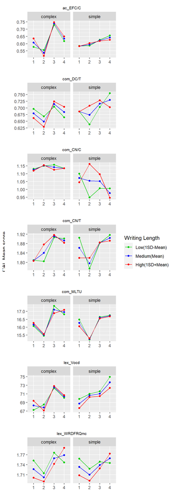

Figure 4. The impact of task repetition on CAL measures moderated by writing length for simple and complex tasks